# 🎬 Project 78 of 100 – Movie Cost vs Revenue Analysis

### A Data Journey with a Colombian Flavor 🇨🇴

Welcome! In this challenge, I explore the relationship between movie production budgets and worldwide revenues.

I am going to:

- Clean a real-world dataset
- Explore patterns visually
- Apply Linear Regression
- Interpret the results ☕📊

Let's dive in, parce!

```python
# Standard data science imports
import pandas as pd
import numpy as np
import matplotlib.pyplot as plt
import seaborn as sns

from sklearn.linear_model import LinearRegression

# Notebook Presentation
pd.options.display.float_format = '{:,.2f}'.format

from pandas.plotting import register_matplotlib_converters
register_matplotlib_converters()

# Make plots look clean and smooth
sns.set_style("whitegrid")

print("All libraries loaded successfully. ¡Vamos con toda!")
```

```
All libraries loaded successfully. ¡Vamos con toda!
```

## 📂 Loading the Dataset

I'm working with movie budget and revenue data.  
Before anything fancy, I load and inspect the dataset.

> First we look at the terrain before planting the coffee 🌱

So let's check:

- How many rows and columns does the dataset contain?
- Are there any NaN values present?
- Are there any duplicate rows?
- What are the data types of the columns?

```python
df = pd.read_csv("cost_revenue_dirty.csv")

df.head()
```

|  | Rank | Release_Date | Movie_Title | USD_Production_Budget | USD_Worldwide_Gross | USD_Domestic_Gross |
| --- | --- | --- | --- | --- | --- | --- |
| 0 | 5293 | 8/2/1915 | The Birth of a Nation | $110,000 | $11,000,000 | $10,000,000 |
| 1 | 5140 | 5/9/1916 | Intolerance | $385,907 | $0 | $0 |
| 2 | 5230 | 12/24/1916 | 20,000 Leagues Under the Sea | $200,000 | $8,000,000 | $8,000,000 |
| 3 | 5299 | 9/17/1920 | Over the Hill to the Poorhouse | $100,000 | $3,000,000 | $3,000,000 |
| 4 | 5222 | 1/1/1925 | The Big Parade | $245,000 | $22,000,000 | $11,000,000 |

```python
print(f'Any NaN values among the data? {df.isna().values.any()}')
print(f'Any duplicates? {df.duplicated().values.any()}')

duplicated_rows = df[df.duplicated()]
print(f'Number of duplicates: {len(duplicated_rows)}')
```

```
Any NaN values among the data? False
Any duplicates? False
Number of duplicates: 0
```

```python
# Show NaN values and data types per column
df.info()
```

```
<class 'pandas.DataFrame'>
RangeIndex: 5391 entries, 0 to 5390
Data columns (total 6 columns):
 #   Column                 Non-Null Count  Dtype
---  ------                 --------------  -----
 0   Rank                   5391 non-null   int64
 1   Release_Date           5391 non-null   str
 2   Movie_Title            5391 non-null   str
 3   USD_Production_Budget  5391 non-null   str
 4   USD_Worldwide_Gross    5391 non-null   str
 5   USD_Domestic_Gross     5391 non-null   str
dtypes: int64(1), str(5)
memory usage: 252.8 KB
```

## 🧹 Cleaning the Data

Real-world data is never perfectly clean.  
First:

- Remove currency symbols
- Convert columns to numeric
- Handle missing values

No shortcuts here — clean data means clean insights.

```python
chars_to_remove = [',', '$']
columns_to_clean = ['USD_Production_Budget',
                    'USD_Worldwide_Gross',
                    'USD_Domestic_Gross']

for col in columns_to_clean:
    for char in chars_to_remove:
        # Replace each character with an empty string
        df[col] = df[col].astype(str).str.replace(char, "")
    # Convert column to a numeric data type
    df[col] = pd.to_numeric(df[col], errors='coerce')

# Convert the Release_Date column to a Pandas Datetime type.
df['Release_Date'] = pd.to_datetime(df['Release_Date'])

# Drop missing values
df.dropna(inplace=True)

df.info()
```

```
<class 'pandas.DataFrame'>
RangeIndex: 5391 entries, 0 to 5390
Data columns (total 6 columns):
 #   Column                 Non-Null Count  Dtype
---  ------                 --------------  -----
 0   Rank                   5391 non-null   int64
 1   Release_Date           5391 non-null   datetime64[us]
 2   Movie_Title            5391 non-null   str
 3   USD_Production_Budget  5391 non-null   int64
 4   USD_Worldwide_Gross    5391 non-null   int64
 5   USD_Domestic_Gross     5391 non-null   int64
dtypes: datetime64[us](1), int64(4), str(1)
memory usage: 252.8 KB
```

```python
df.head()
```

|  | Rank | Release_Date | Movie_Title | USD_Production_Budget | USD_Worldwide_Gross | USD_Domestic_Gross |
| --- | --- | --- | --- | --- | --- | --- |
| 0 | 5293 | 1915-08-02 | The Birth of a Nation | 110000 | 11000000 | 10000000 |
| 1 | 5140 | 1916-05-09 | Intolerance | 385907 | 0 | 0 |
| 2 | 5230 | 1916-12-24 | 20,000 Leagues Under the Sea | 200000 | 8000000 | 8000000 |
| 3 | 5299 | 1920-09-17 | Over the Hill to the Poorhouse | 100000 | 3000000 | 3000000 |
| 4 | 5222 | 1925-01-01 | The Big Parade | 245000 | 22000000 | 11000000 |

## 📊 Descriptive Statistics – Let’s Read the Numbers Carefully

Before building models, let's pause and look at the raw story the data is telling us.

*“Before making conclusions, sit down and look at the numbers calmly.”* ☕

#### Questions We Want to Answer:

- What is the average production budget of the films in the dataset?
- What is the average worldwide gross revenue?
- What are the minimum domestic and worldwide revenues?
- Are the bottom 25% of films profitable?
- What are the highest production budget and highest worldwide gross revenue?
- How much revenue did the lowest and highest budget films make?

```python
# Summary statistics for all numerical columns
df.describe()
```

|  | Rank | Release_Date | USD_Production_Budget | USD_Worldwide_Gross | USD_Domestic_Gross |
| --- | --- | --- | --- | --- | --- |
| count | 5,391.00 | 5391 | 5,391.00 | 5,391.00 | 5,391.00 |
| mean | 2,696.00 | 2003-09-19 15:02:02.203672 | 31,113,737.58 | 88,855,421.96 | 41,235,519.44 |
| min | 1.00 | 1915-08-02 00:00:00 | 1,100.00 | 0.00 | 0.00 |
| 25% | 1,348.50 | 1999-12-02 12:00:00 | 5,000,000.00 | 3,865,206.00 | 1,330,901.50 |
| 50% | 2,696.00 | 2006-06-23 00:00:00 | 17,000,000.00 | 27,450,453.00 | 17,192,205.00 |
| 75% | 4,043.50 | 2011-11-23 00:00:00 | 40,000,000.00 | 96,454,455.00 | 52,343,687.00 |
| max | 5,391.00 | 2020-12-31 00:00:00 | 425,000,000.00 | 2,783,918,982.00 | 936,662,225.00 |
| std | 1,556.39 | NaN | 40,523,796.88 | 168,457,757.00 | 66,029,346.27 |

#### 🎯 Key Insights from the Summary

From the descriptive table:

- Average production budget: about 31 million
- Average worldwide gross revenue: about 88 million
- Minimum worldwide revenue: 0
- Minimum domestic revenue: 0
- Highest production budget: 425 million
- Highest worldwide revenue: about 2.78 billion

Now let’s investigate the extremes.

### 💰 Lowest and Highest Budget Films

```python
# Film with the lowest production budget
min_index=df['USD_Production_Budget'].idxmin()
df.loc[min_index]
```

```
Rank                                    5391
Release_Date             2005-05-08 00:00:00
Movie_Title                My Date With Drew
USD_Production_Budget                   1100
USD_Worldwide_Gross                   181041
USD_Domestic_Gross                    181041
Name: 2427, dtype: object
```

👉 The lowest budget film had a budget of $1,100.

```python
# Film with the highest production budget
max_index=df['USD_Production_Budget'].idxmax()
df.loc[max_index]
```

```
Rank                                       1
Release_Date             2009-12-18 00:00:00
Movie_Title                           Avatar
USD_Production_Budget              425000000
USD_Worldwide_Gross               2783918982
USD_Domestic_Gross                 760507625
Name: 3529, dtype: object
```

👉 The highest budget film invested $425 million.

### 🚨 Zero Domestic Revenue

Now things get interesting.

How many films made **$0 in the United States**? And which high-budget films earned nothing domestically?

```python
zero_domestic = df[df['USD_Domestic_Gross'] == 0]

print(f'Number of films that grossed $0 domestically: {len(zero_domestic)}')

zero_domestic.sort_values('USD_Production_Budget', ascending=False)
```

```
Number of films that grossed $0 domestically: 512
```

|  | Rank | Release_Date | Movie_Title | USD_Production_Budget | USD_Worldwide_Gross | USD_Domestic_Gross |
| --- | --- | --- | --- | --- | --- | --- |
| 5388 | 96 | 2020-12-31 | Singularity | 175000000 | 0 | 0 |
| 5387 | 126 | 2018-12-18 | Aquaman | 160000000 | 0 | 0 |
| 5384 | 321 | 2018-09-03 | A Wrinkle in Time | 103000000 | 0 | 0 |
| 5385 | 366 | 2018-10-08 | Amusement Park | 100000000 | 0 | 0 |
| 5090 | 556 | 2015-12-31 | Don Gato, el inicio de la pandilla | 80000000 | 4547660 | 0 |
| ... | ... | ... | ... | ... | ... | ... |
| 4787 | 5371 | 2014-12-31 | Stories of Our Lives | 15000 | 0 | 0 |
| 3056 | 5374 | 2007-12-31 | Tin Can Man | 12000 | 0 | 0 |
| 4907 | 5381 | 2015-05-19 | Family Motocross | 10000 | 0 | 0 |
| 5006 | 5389 | 2015-09-29 | Signed Sealed Delivered | 5000 | 0 | 0 |
| 5007 | 5390 | 2015-09-29 | A Plague So Pleasant | 1400 | 0 | 0 |

512 rows × 6 columns

📌 Over 500 films made zero domestic revenue.

That includes some surprisingly high-budget productions. Sometimes a film skips U.S. theaters or underperforms completely.

### 🌍 Zero Worldwide Revenue

Now the bigger question:

How many films earned absolutely nothing worldwide?

```python
zero_worldwide = df[df['USD_Worldwide_Gross'] == 0]

print(f'Number of films that grossed $0 worldwide: {len(zero_worldwide)}')

zero_worldwide.sort_values('USD_Production_Budget', ascending=False)
```

```
Number of films that grossed $0 worldwide: 357
```

|  | Rank | Release_Date | Movie_Title | USD_Production_Budget | USD_Worldwide_Gross | USD_Domestic_Gross |
| --- | --- | --- | --- | --- | --- | --- |
| 5388 | 96 | 2020-12-31 | Singularity | 175000000 | 0 | 0 |
| 5387 | 126 | 2018-12-18 | Aquaman | 160000000 | 0 | 0 |
| 5384 | 321 | 2018-09-03 | A Wrinkle in Time | 103000000 | 0 | 0 |
| 5385 | 366 | 2018-10-08 | Amusement Park | 100000000 | 0 | 0 |
| 5058 | 880 | 2015-11-12 | The Ridiculous 6 | 60000000 | 0 | 0 |
| ... | ... | ... | ... | ... | ... | ... |
| 4787 | 5371 | 2014-12-31 | Stories of Our Lives | 15000 | 0 | 0 |
| 3056 | 5374 | 2007-12-31 | Tin Can Man | 12000 | 0 | 0 |
| 4907 | 5381 | 2015-05-19 | Family Motocross | 10000 | 0 | 0 |
| 5006 | 5389 | 2015-09-29 | Signed Sealed Delivered | 5000 | 0 | 0 |
| 5007 | 5390 | 2015-09-29 | A Plague So Pleasant | 1400 | 0 | 0 |

357 rows × 6 columns

📌 Hundreds of films reported zero worldwide revenue.

This may include:

- Limited releases
- Reporting gaps
- Direct-to-streaming films
- Or movies that simply never made it to market

Not every production becomes a box office story.

### 🌎 International Releases Only

Some films made money internationally  
but zero revenue in the U.S.

Let’s isolate them.

```python
international_releases = df.loc[
    (df['USD_Domestic_Gross'] == 0) &
    (df['USD_Worldwide_Gross'] != 0)
]

print(f'Number of international releases: {len(international_releases)}')

international_releases.head()
```

```
Number of international releases: 155
```

|  | Rank | Release_Date | Movie_Title | USD_Production_Budget | USD_Worldwide_Gross | USD_Domestic_Gross |
| --- | --- | --- | --- | --- | --- | --- |
| 71 | 4310 | 1956-02-16 | Carousel | 3380000 | 3220 | 0 |
| 1579 | 5087 | 2001-02-11 | Everything Put Together | 500000 | 7890 | 0 |
| 1744 | 3695 | 2001-12-31 | The Hole | 7500000 | 10834406 | 0 |
| 2155 | 4236 | 2003-12-31 | Nothing | 4000000 | 63180 | 0 |
| 2203 | 2513 | 2004-03-31 | The Touch | 20000000 | 5918742 | 0 |

Now using `.query()` for a cleaner syntax:

```python
international_releases = df.query(
    'USD_Domestic_Gross == 0 and USD_Worldwide_Gross != 0'
)

print(f'Number of international releases: {len(international_releases)}')

international_releases.tail()
```

```
Number of international releases: 155
```

|  | Rank | Release_Date | Movie_Title | USD_Production_Budget | USD_Worldwide_Gross | USD_Domestic_Gross |
| --- | --- | --- | --- | --- | --- | --- |
| 5340 | 1506 | 2017-04-14 | Queen of the Desert | 36000000 | 1480089 | 0 |
| 5348 | 2225 | 2017-05-05 | Chāi dàn zhuānjiā | 23000000 | 58807172 | 0 |
| 5360 | 4832 | 2017-07-03 | Departure | 1100000 | 27561 | 0 |
| 5372 | 1856 | 2017-08-25 | Ballerina | 30000000 | 48048527 | 0 |
| 5374 | 4237 | 2017-08-25 | Polina danser sa vie | 4000000 | 36630 | 0 |

Same result. Cleaner code. Muy elegante.

### 🗓️ Removing Films Not Yet Released

The dataset was collected on May 1st, 2018.

Some films had release dates after that.  
That means they had no real chance to generate box office revenue yet.

We should exclude them for fairness.

```python
# Date of data collection
scrape_date = pd.Timestamp('2018-5-1')

future_releases = df[df.Release_Date >= scrape_date]

print(f'Number of unreleased movies: {len(future_releases)}')

future_releases
```

```
Number of unreleased movies: 7
```

|  | Rank | Release_Date | Movie_Title | USD_Production_Budget | USD_Worldwide_Gross | USD_Domestic_Gross |
| --- | --- | --- | --- | --- | --- | --- |
| 5384 | 321 | 2018-09-03 | A Wrinkle in Time | 103000000 | 0 | 0 |
| 5385 | 366 | 2018-10-08 | Amusement Park | 100000000 | 0 | 0 |
| 5386 | 2950 | 2018-10-08 | Meg | 15000000 | 0 | 0 |
| 5387 | 126 | 2018-12-18 | Aquaman | 160000000 | 0 | 0 |
| 5388 | 96 | 2020-12-31 | Singularity | 175000000 | 0 | 0 |
| 5389 | 1119 | 2020-12-31 | Hannibal the Conqueror | 50000000 | 0 | 0 |
| 5390 | 2517 | 2020-12-31 | Story of Bonnie and Clyde, The | 20000000 | 0 | 0 |

```python
# Exclude future releases
df_clean = df.drop(future_releases.index)

# Confirm removal
df.shape[0] - df_clean.shape[0]
```

```
7
```

Only a small number of films were unreleased — but removing them keeps the analysis honest.

Clean data. Clean conscience.

### 📉 Films That Lost Money

Now the tough question:

What percentage of films cost more to produce than they earned worldwide?

In simple terms: how many films lost money?

```python
money_losing = df_clean.query(
    'USD_Production_Budget > USD_Worldwide_Gross'
)

money_losing.shape[0] / df_clean.shape[0]
```

```
0.37277117384843983
```

📌 Roughly 37% of films lost money.

That means more than 1 out of 3 films did not recover their production costs.

### 🕰️ Converting Years to Decades – A Clean Data Trick

Time to organize the films historically.

Instead of analyzing individual years, let's group movies by **decade**. This helps us see broader trends.

Here’s the plan:

1. Convert `Release_Date` into a `DatetimeIndex`
2. Extract the year
3. Use floor division (`//`) to convert years into decades
4. Add a new column called `Decade`

Simple. Elegant. Effective.

```python
# Create a DatetimeIndex from Release_Date
dt_index = pd.DatetimeIndex(df_clean.Release_Date)

# Extract years
years = dt_index.year

years[:5]
```

```
Index([1915, 1916, 1916, 1920, 1925], dtype='int32', name='Release_Date')
```

Now let’s understand the decade conversion logic.

```python
# Example: How does 1999 become 1990?

1999 // 10
```

```
199
```

```python
1999 // 10 * 10
```

```
1990
```

That’s the trick. Floor division removes the last digit. Then multiplying by 10 rebuilds the decade.

Now we apply it to the full dataset.

```python
# Convert years to decades
decades = years // 10 * 10

# Add new column to the DataFrame
df_clean['Decade'] = decades

df_clean.head()
```

|  | Rank | Release_Date | Movie_Title | USD_Production_Budget | USD_Worldwide_Gross | USD_Domestic_Gross | Decade |
| --- | --- | --- | --- | --- | --- | --- | --- |
| 0 | 5293 | 1915-08-02 | The Birth of a Nation | 110000 | 11000000 | 10000000 | 1910 |
| 1 | 5140 | 1916-05-09 | Intolerance | 385907 | 0 | 0 | 1910 |
| 2 | 5230 | 1916-12-24 | 20,000 Leagues Under the Sea | 200000 | 8000000 | 8000000 | 1910 |
| 3 | 5299 | 1920-09-17 | Over the Hill to the Poorhouse | 100000 | 3000000 | 3000000 | 1920 |
| 4 | 5222 | 1925-01-01 | The Big Parade | 245000 | 22000000 | 11000000 | 1920 |

Clean, organized, and ready for historical comparisons.

### 🎬 Old vs New Films

Now let’s split the dataset into two eras:

- **Old Films:** Released up to and including 1969
- **New Films:** Released from 1970 onwards

We want to know:

- How many films were released before 1970?
- What was the most expensive film made before 1970?

```python
# Separate datasets
old_films = df_clean[df_clean.Decade <= 1960]
new_films = df_clean[df_clean.Decade > 1960]

len(old_films)
```

```
153
```

So we have over a hundred films from the earlier cinema era.

Let’s examine their statistics.

```python
old_films.describe()
```

|  | Rank | Release_Date | USD_Production_Budget | USD_Worldwide_Gross | USD_Domestic_Gross | Decade |
| --- | --- | --- | --- | --- | --- | --- |
| count | 153.00 | 153 | 153.00 | 153.00 | 153.00 | 153.00 |
| mean | 4,274.77 | 1954-06-10 04:04:42.352942 | 4,611,297.65 | 30,419,634.38 | 22,389,473.87 | 1,949.15 |
| min | 1,253.00 | 1915-08-02 00:00:00 | 100,000.00 | 0.00 | 0.00 | 1,910.00 |
| 25% | 3,973.00 | 1946-01-01 00:00:00 | 1,250,000.00 | 5,273,000.00 | 5,000,000.00 | 1,940.00 |
| 50% | 4,434.00 | 1956-12-23 00:00:00 | 2,900,000.00 | 10,000,000.00 | 10,000,000.00 | 1,950.00 |
| 75% | 4,785.00 | 1964-10-22 00:00:00 | 5,000,000.00 | 33,208,099.00 | 28,350,000.00 | 1,960.00 |
| max | 5,299.00 | 1969-12-19 00:00:00 | 42,000,000.00 | 390,525,192.00 | 198,680,470.00 | 1,960.00 |
| std | 742.14 | NaN | 5,713,648.85 | 54,931,828.93 | 32,641,752.41 | 12.72 |

From this summary:

- Average production budgets were much lower than modern films
- Revenue distributions were also very different
- The scale of cinema has dramatically changed over time

Now let’s find the most expensive pre-1970 film.

```python
old_films.sort_values('USD_Production_Budget', ascending=False).head()
```

|  | Rank | Release_Date | Movie_Title | USD_Production_Budget | USD_Worldwide_Gross | USD_Domestic_Gross | Decade |
| --- | --- | --- | --- | --- | --- | --- | --- |
| 109 | 1253 | 1963-12-06 | Cleopatra | 42000000 | 71000000 | 57000000 | 1960 |
| 150 | 2175 | 1969-12-16 | Hello, Dolly | 24000000 | 33208099 | 33208099 | 1960 |
| 118 | 2425 | 1965-02-15 | The Greatest Story Ever Told | 20000000 | 15473333 | 15473333 | 1960 |
| 143 | 2465 | 1969-01-01 | Sweet Charity | 20000000 | 8000000 | 8000000 | 1960 |
| 148 | 2375 | 1969-10-15 | Paint Your Wagon | 20000000 | 31678778 | 31678778 | 1960 |

One standout classic invested tens of millions — which, for that era, was a massive bet.

Old Hollywood was already thinking big.

## 📊 Visual Exploration

Time to visualize the relationship between budget and revenue.

Is spending more money strongly related to earning more money?  
Let's see what the scatter plot tells us.

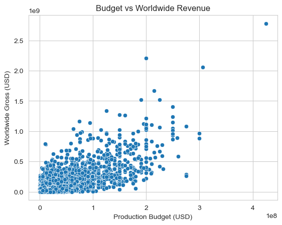

```python
plt.figure()
sns.scatterplot(
    x=df_clean['USD_Production_Budget'],
    y=df_clean['USD_Worldwide_Gross']
)

plt.xlabel("Production Budget (USD)")
plt.ylabel("Worldwide Gross (USD)")
plt.title("Budget vs Worldwide Revenue")

plt.show()
```

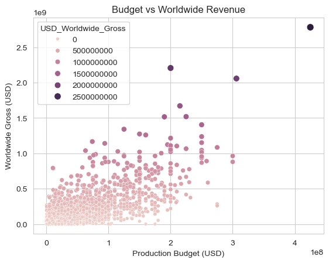

```python
plt.figure()
sns.scatterplot(
    x=df['USD_Production_Budget'],
    y=df['USD_Worldwide_Gross'],
    hue=df['USD_Worldwide_Gross'], # change colour
    size=df['USD_Worldwide_Gross'],) # change size of dot

plt.xlabel("Production Budget (USD)")
plt.ylabel("Worldwide Gross (USD)")
plt.title("Budget vs Worldwide Revenue")

plt.show()
```

### Seaborn Regression Plots

Let’s visualize the relationship between production budget and revenue for films released before 1970.

Does the same positive pattern exist?

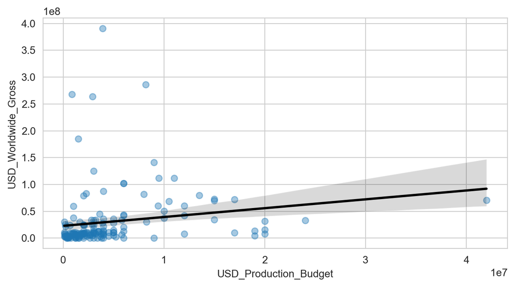

```python
plt.figure(figsize=(8,4), dpi=200)

with sns.axes_style("whitegrid"):
    sns.regplot(
        data=old_films,
        x='USD_Production_Budget',
        y='USD_Worldwide_Gross',
        scatter_kws={'alpha': 0.4},
        line_kws={'color': 'black'}
    )
```

Even in the classic era, we observe a positive relationship.

Cinema evolved. Budgets exploded. Returns followed.

History matters in data.

#### 🔥 Classic vs Modern Cinema – Side-by-Side Comparison

Now things get interesting.

But how does the classic era compare with modern cinema?

Has the relationship between budget and revenue changed?

Let’s visualize both eras separately and then interpret the difference.

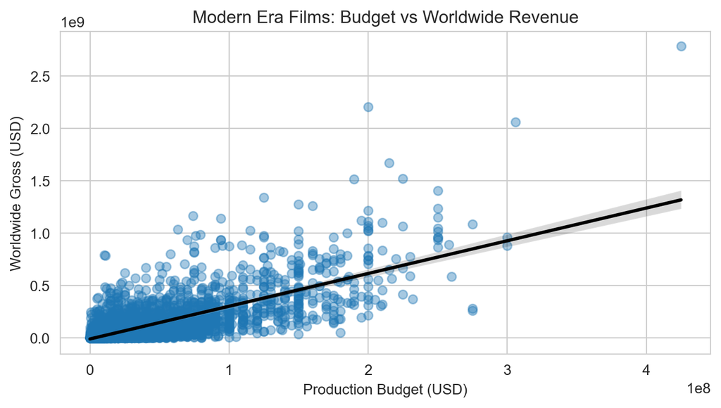

```python
plt.figure(figsize=(8,4), dpi=200)

with sns.axes_style("whitegrid"):
    sns.regplot(
        data=new_films,
        x='USD_Production_Budget',
        y='USD_Worldwide_Gross',
        scatter_kws={'alpha': 0.4},
        line_kws={'color': 'black'}
    )

plt.title("Modern Era Films: Budget vs Worldwide Revenue")
plt.xlabel("Production Budget (USD)")
plt.ylabel("Worldwide Gross (USD)")

plt.show()
```

Immediately we notice:

- Much larger budget scale
- Much higher revenue potential
- More extreme outliers

Modern cinema operates on a completely different financial level.

## 📈 Linear Regression Model

Now let's train a Linear Regression model.

The question to answer: **How much revenue can we expect based on production budget?**

Simple model. Powerful insight.

```python
# Old era model
X_old = old_films[['USD_Production_Budget']]
y_old = old_films['USD_Worldwide_Gross']

model_old = LinearRegression()
model_old.fit(X_old, y_old)

# New era model
X_new = new_films[['USD_Production_Budget']]
y_new = new_films['USD_Worldwide_Gross']

model_new = LinearRegression()
model_new.fit(X_new, y_new)

print("Old Era Slope:", model_old.coef_[0])
print("New Era Slope:", model_new.coef_[0])

print(f"\nOld Era Intercept:", model_old.intercept_)
print("New Era Intercept:", model_new.intercept_)

print(f"\nOld Era R2:", model_old.score(X_old, y_old))
print("New Era R2:", model_new.score(X_new, y_new))
```

```
Old Era Slope: 1.6477131440107315
New Era Slope: 3.1225959173210964

Old Era Intercept: 22821538.635080386
New Era Intercept: -8650768.006610379

Old Era R2: 0.02937258620576877
New Era R2: 0.5577032617720403
```

## 🔮 Making Predictions

Let’s predict the revenue of a movie with a hypothetical budget.

Because in data science, we don’t just analyze — we forecast.

```python
sample_budget = np.array([[100_000_000]])  # 100 million USD

predicted_revenue = model_new.predict(sample_budget)

print(f"Estimated revenue for a $100M movie: ${predicted_revenue[0]:,.2f}")
```

```
Estimated revenue for a $100M movie: $303,608,823.73
```

## 🧠 Final Thoughts

There is a positive relationship between production budget and worldwide revenue.

Does spending more guarantee success? Not always —  
but statistically speaking, bigger budgets tend to generate higher gross revenues.

And that’s the beauty of data: It doesn’t guess. It measures.